## **Woylie**

### Blamed on cats

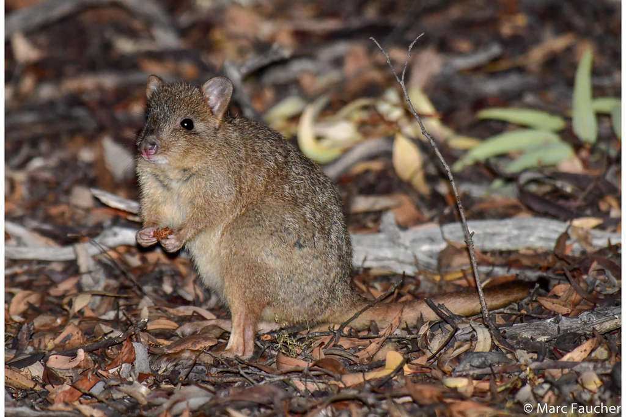

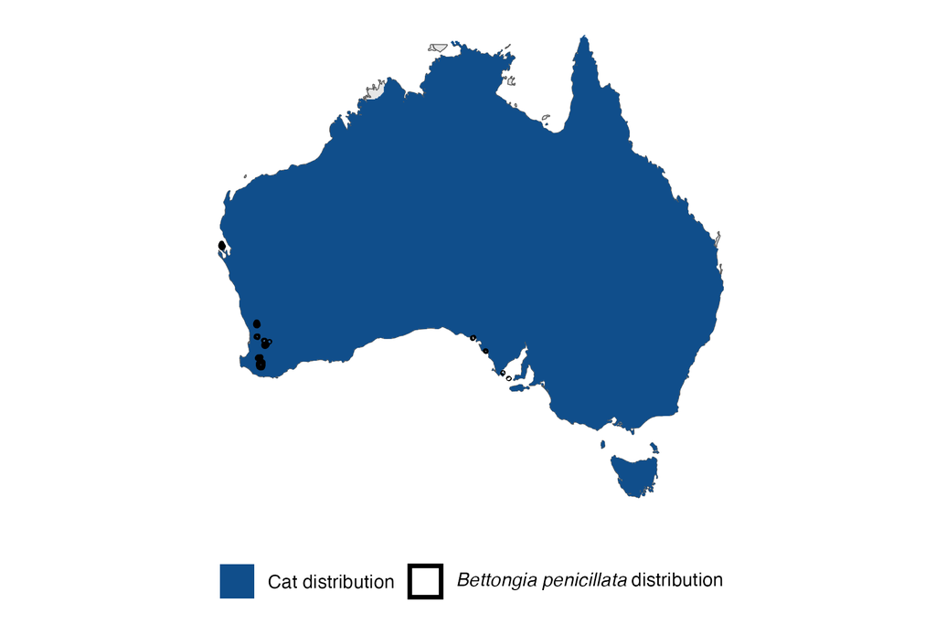

IUCN status: **Critically Endangered**

EPBC Predator Threat Rating: **High/Very High**

IUCN claim: *“The major reason for past decline has been predation by Red Foxes and feral cats”*

### Is the threat claim evidence-based?

No studies were found evidencing a negative association between cats and woylie populations. The fate of reintroduced animals is not a reliable proxy for the fate of populations.

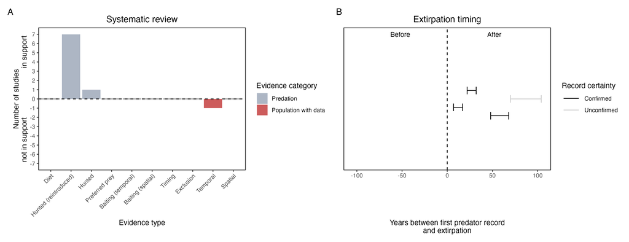

**Evidence linking *Bettongia penicillata* to cats.** **A.** Systematic review of evidence for an association between *Bettongia penicillata* and cats. Positive studies are in support of the hypothesis that cats contribute to the decline of *Bettongia penicillata*, negative studies are not in support. Predation studies include studies documenting hunting or scavenging; baiting studies are associations between poison baiting and threatened mammal abundance where information on predator abundance is not provided; population studies are associations between threatened mammal and predator abundance. Gold borders indicate studies that meet qualities of scientific rigour. **B.** Last records of extirpated populations relative to earliest local records of cats. Error bars show minimum and maximum extinction intervals. Predator arrival records were digitized from Abbott 2008. See methods section in Wallach and Lundgren 2025 for details on evidence categories.

### References

Abbott, The spread of the cat, Felis catus, in Australia: re-examination of the current conceptual model with additional information. Conservation Science Western Australia 7 (2008).

EPBC. (2015) Threat Abatement Plan for Predation by Feral Cats. Environment Protection and Biodiversity Conservation Act 1999, Department of Environment, Government of Australia. (Table A1).

IUCN Red List. https://www.iucnredlist.org/ Accessed June 2023

James, H., Acharya, A.B., Taylor, J.A. and Freak, M.J., 2002. A case of bitten bettongs. The Journal of Forensic Odonto-Stomatology-JFOS, 20(1), pp.10-12.

Marlow, N.J., Thomas, N.D., Williams, A.A., Macmahon, B., Lawson, J., Hitchen, Y., Angus, J. and Berry, O., 2015. Cats (Felis catus) are more abundant and are the dominant predator of woylies (Bettongia penicillata) after sustained fox (Vulpes vulpes) control. Australian Journal of Zoology, 63(1), pp.18-27.

Martin, S., Ball, S. and Peeters, P., 2006. Reintroduction of the brush-tailed Bettong (Bettongia penicillata ogilbyi) into Lincoln National Park.Program review from September 1999 to July 2004. Department for Environment and Heritage, Government of South Australia.

Priddel, D. and Wheeler, R., 2004. An experimental translocation of brush-tailed bettongs (Bettongia penicillata) to western New South Wales. Wildlife Research, 31(4), pp.421-432.

Wallach A.D., Lundgren E.J. (2025) Review of evidence that foxes and cats cause extinctions of Australia’s endemic mammals. BioScience. DOI: 10.1093/biosci/biaf046

Wayne, A.F., Maxwell, M.A., Ward, C.G., Wayne, J.C., Vellios, C.V. and Wilson, I.J., 2017. Recoveries and cascading declines of native mammals associated with control of an introduced predator. Journal of Mammalogy, 98(2), pp.489-501.

Wheeler, R. and Priddel, D., 2009. The impact of introduced predators on two threatened prey species: A case study from western New South Wales. Ecological Management & Restoration, 10, pp.S117-S123.